# Urban Big Data Analytics - Assignment 4

Andy Hong

July 29, 2019

# Prerequisites

First, create a folder named `assignments` under the `vsp_bigdata` folder in your Documents folder.

**IMPORTANT - PLEASE FOLLOW THE EXACT FOLDER NAME. OTHERWISE, YOU WILL GET LOST.**

Now, let’s download the gapminder data set from this link: [Gapminder 2016 CSV file](http://urbanbigdata.github.io/99-assignments/assignment-4/gapminder_data_2016.csv) .

Now, download the gapminder geographic coordinate file from this link: [Gapminder geographic coordinate file](http://urbanbigdata.github.io/99-assignments/assignment-4/gapminder_geo.csv) .

Once you downloaded the files, move or copy the files to the `assignments` folder you just created.

Next, please download a clean R template file here: [Assignment 4 template R file](http://urbanbigdata.github.io/99-assignments/assignment-4/Assignment_4_template.R) .  
Make sure to save this R template file under the `assignments` folder you just created.

Finally, let’s run the R Studio program. Once the R Studio is loaded, you can open the assignment 4 template R file. The R template file should be a blank script with the header description below.

```r
###########################################
#
# VSP Urban Big Data Assignment 4
#
# Title: Data visualization with Gapminder data
# Group number: <your input>
# Name: <your input>
# Date: <your input>
#
###########################################
```

# Instructions

## 1. Synopsis

The purpose of this assignment is to get you familiar with data visualization in R. By now, you must be quite familiar with the **Gapminder** data from your previous assignments. For this assignment, you will work with the gapminder data for 2016, and the coordinate data available for each countryin the gapminder data. This assignment will walk you through how to load the data and do a basic data visualization.

## 2. Basic setup

### Install required package

For the assignment 4, you will need to install the five packages listed velow. These packages allow you to use core functions to do a data visualization and web mapping. You will also need to download the gapminder datasets and load the data to R Studio.

```r
install.packages("dplyr")
install.packages("magrittr")
install.packages("ggplot2")
install.packages("plotly")
install.packages("leaflet")
```

### Load the package

```r
library(dplyr)
library(magrittr)
library(ggplot2)
library(plotly)
library(leaflet)
```

### Gapminder dataset

Now, let’s load the gapminder file to the R Studio environment.  
**Make sure to change `[your user name]` with your own user name for the path.**

```r
# For Windows
gapminder = read.csv("C://Users//[your user name]//Documents//vsp_bigdata//assignments//gapminder_data_2016.csv")
geo = read.csv("C://Users//[your user name]//Documents//vsp_bigdata//assignments//gapminder_geo.csv")

# For Mac
gapminder = read.csv("/Users/[your user name]/Documents/vsp_bigdata/assignments/gapminder_data_2016.csv")
geo = read.csv("/Users/[your user name]/Documents/vsp_bigdata/assignments/gapminder_geo.csv")
```

The gapminder 2016 dataset has 4 variables and 187 observations. Let’s take look at the first 6 rows of the data.

```r
head(gapminder)
```

```
##                  name   region income lifeExp
## 1         Afghanistan     asia   1740    58.0
## 2             Albania   europe  11400    77.7
## 3             Algeria   africa  14000    77.4
## 4             Andorra   europe  48200    82.5
## 5              Angola   africa   6030    64.7
## 6 Antigua and Barbuda americas  20800    77.3
```

Now let’s take a look at the geographic coordinate data.

```r
head(geo)
```

```
##                  name       lat      long population
## 1         Afghanistan  33.00000  66.00000   34700000
## 2             Albania  41.00000  20.00000    2930000
## 3             Algeria  28.00000   3.00000   40600000
## 4             Andorra  42.50779   1.52109      77300
## 5              Angola -12.50000  18.50000   28800000
## 6 Antigua and Barbuda  17.05000 -61.80000     101000
```

## 3. Data joining in R

We can use the column `name` to join the two data sets together to prepare for mapping later. We are going to use `inner_join` so that we only choose countries with complete geographic data.

```r
# Join gapminder data and the geographic coordinates
gapminder = gapminder %>% inner_join(geo, by="name")

# Check the joined data
head(gapminder)
```

```
##                  name   region income lifeExp       lat      long
## 1         Afghanistan     asia   1740    58.0  33.00000  66.00000
## 2             Albania   europe  11400    77.7  41.00000  20.00000
## 3             Algeria   africa  14000    77.4  28.00000   3.00000
## 4             Andorra   europe  48200    82.5  42.50779   1.52109
## 5              Angola   africa   6030    64.7 -12.50000  18.50000
## 6 Antigua and Barbuda americas  20800    77.3  17.05000 -61.80000
##   population
## 1   34700000
## 2    2930000
## 3   40600000
## 4      77300
## 5   28800000
## 6     101000
```

### Key functions for data visualization in R

We will use the `ggplot2` package, which allows you to use the following data visualization functions.

```r
geom_histogram() # histogram
geom_point() # scatter plot
geom_smooth() # trend line
geom_bar() # bar plot
geom_line() # line plot
```

For this assignment, we will use the three visualization functions: `geom_histogram()`, `geom_point()`, `geom_smooth()`.

### Initialize ggplot

To initialize ggplot functions, you will need to use the ggplot function and declare x and y axes. `aes` is short for “aesthetic”, and what go inside this parameter are the variables that can be pulled from the data.

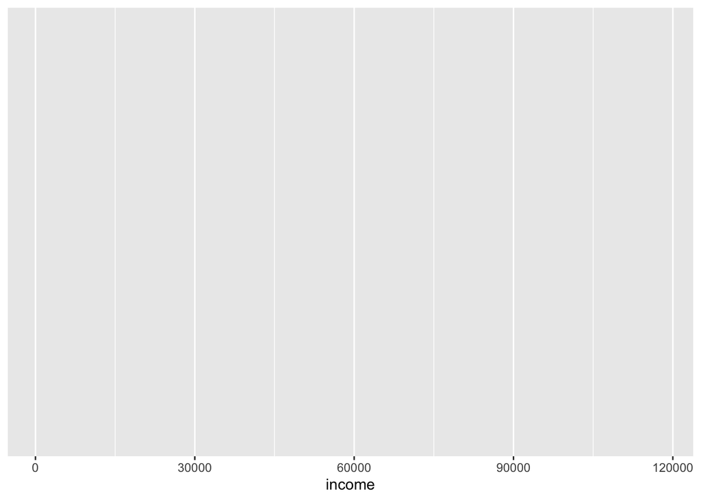

```r
ggplot(gapminder, aes(x = income))
```

You will see a blank plot without any data in it, but that’s okay.

### **geom_histogram( )** function:

This function allows you to create a histogram using the x-axis variable inside the `aes` parameter.

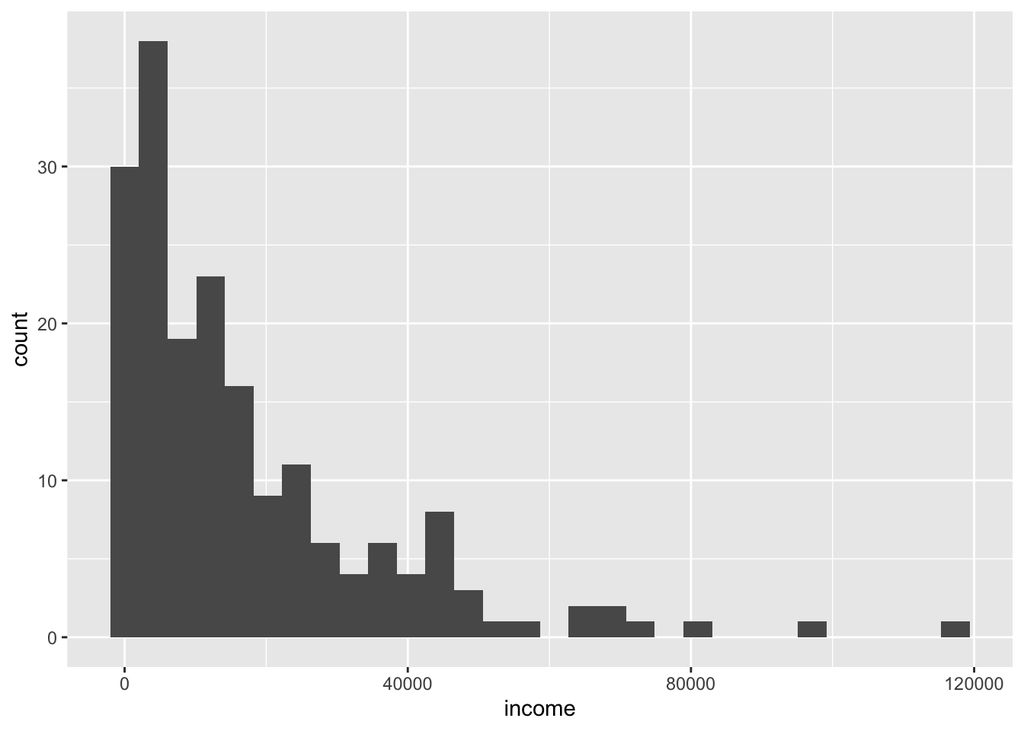

```r
ggplot(gapminder, aes(x = income)) + geom_histogram()
```

### **geom_point( )** function:

This function allows you to create a scatter plot using x and y axes inside the `aes` parameter.

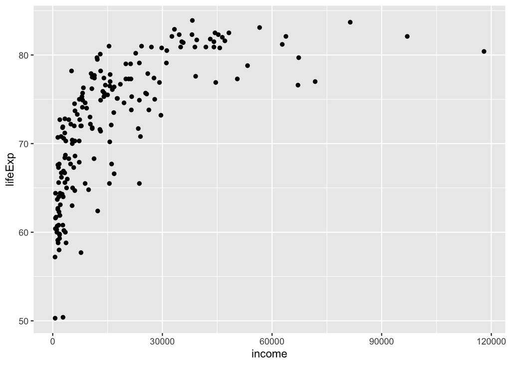

```r
ggplot(gapminder, aes(x = income, y=lifeExp)) + geom_point()
```

The graph looks non-linear, so we can take a log of income or can use a log scale for the x-axis.

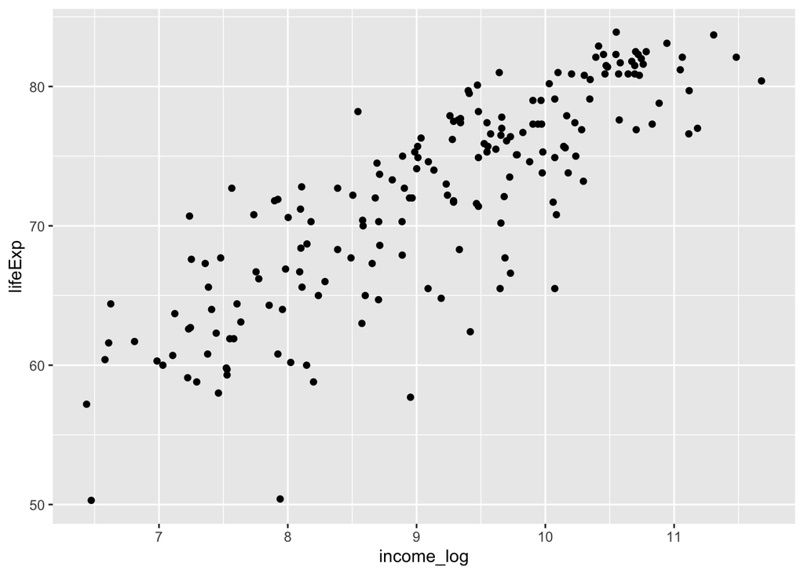

```r
# Create a log-transformed income variable
gapminder = gapminder %>% mutate(income_log = log(income))

# Plot again with the log-transformed income
ggplot(gapminder, aes(x = income_log, y=lifeExp)) + geom_point()
```

Of we can apply a log-scale only for plotting.

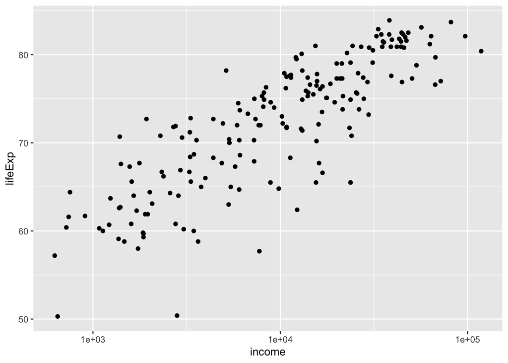

```r
# Plot again with a log scale applied to the x-axis
ggplot(gapminder, aes(x = income, y=lifeExp)) + geom_point() + scale_x_log10()
```

### **geom_boxplot( )** function:

This function allows you to create a boxplot. The X-axis should be a categorical variable, and the Y-axis a continuous numeric variable. Note that `geom_jitter` function allows you to spread the points.

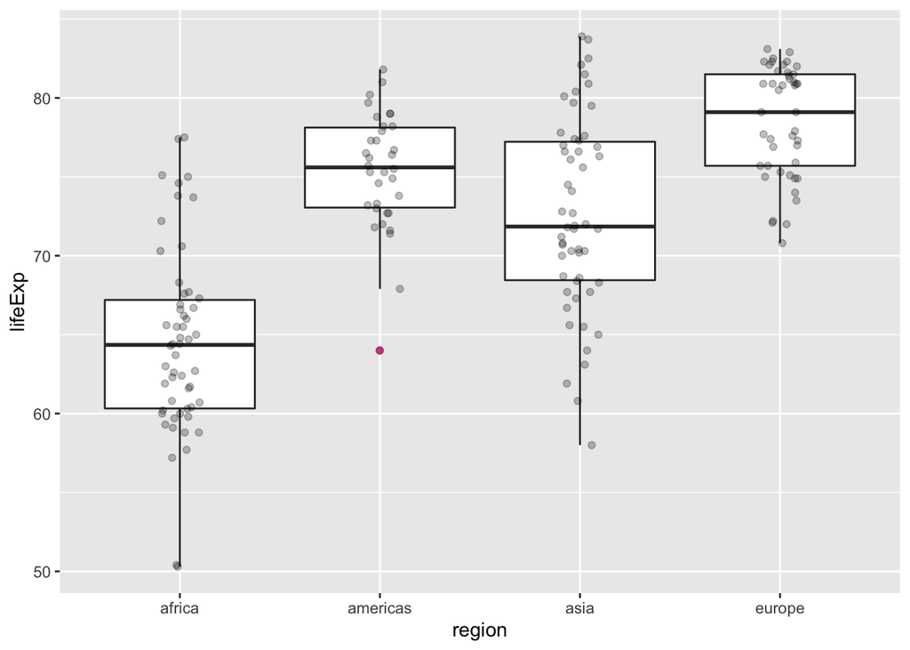

```r
ggplot(gapminder, aes(x = region, y = lifeExp)) +
  geom_boxplot(outlier.colour = "hotpink") +
  geom_jitter(position = position_jitter(width = 0.1, height = 0), alpha = 1/4)
```

The `geom_jitter` is not necessary but addes more depth into our visualization.

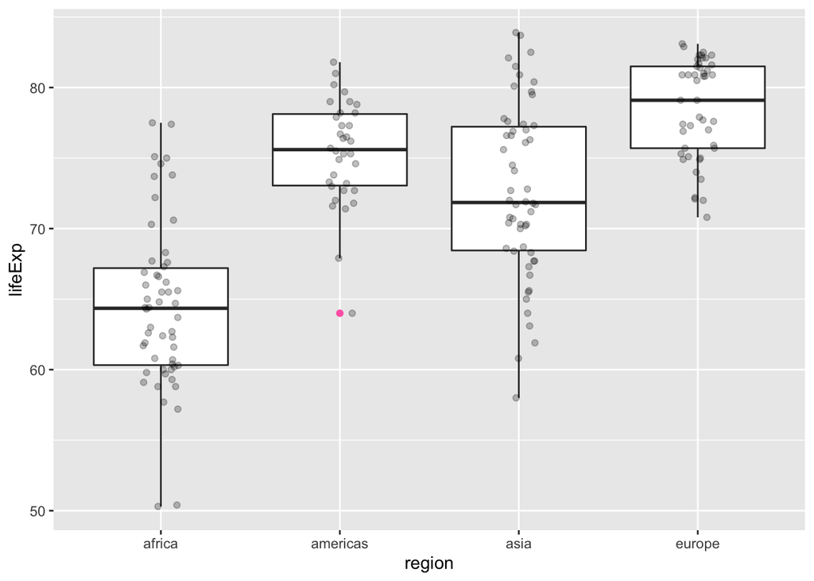

```r
ggplot(gapminder, aes(x = region, y = lifeExp)) +
  geom_boxplot(outlier.colour = "hotpink") +
  geom_jitter(position = position_jitter(width = 0.1, height = 0), alpha = 1/4)
```

### **geom_smooth( )** function:

Creates a trend line using models, such as a linear regression, a local regression, and polynomial functions.

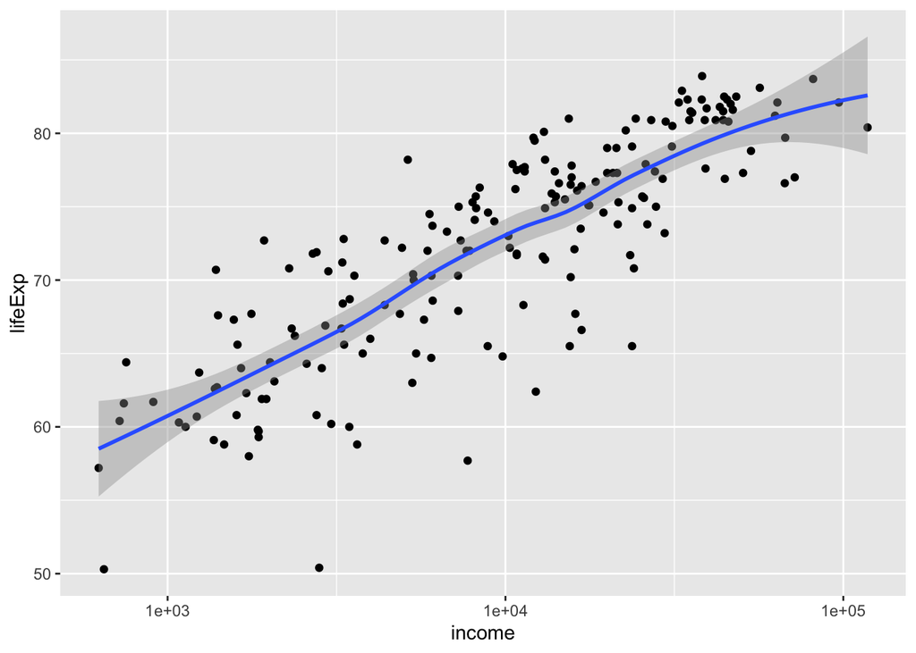

```r
# Plot a trend line
ggplot(gapminder, aes(x = income, y=lifeExp)) + geom_point() + geom_smooth() + scale_x_log10()
```

Now, we will cut the data into four continents using the `facet_grid` function. It is a very useful function to cut data differently and see ther patterns.

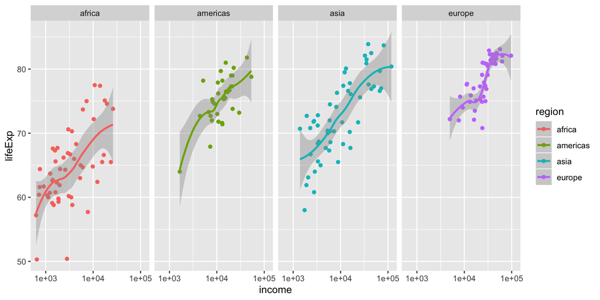

```r
ggplot(gapminder, aes(x = income, y = lifeExp)) +
  geom_point(aes(color = region)) +
  geom_smooth(aes(color = region)) +
  facet_grid(.~region) +
  scale_x_log10()
```

## **Task 1**

Modify the R code chunk above to create one histogram for `population`, one histogram for `income`, and one histogram for life expectancy `lifeExp`. Describe your graphs (e.g. mean and distribution).  
*Hint: you may use `geom_histogram()`.*

## **Task 2**

Modify the R code chunk above to create a scatter plot and a trend line showing the relationship between income and life expectancy by continent. Please transform the variable accordingly. Describe your graph.  
*Hint: you may use `geom_point()` and `geom_smooth()`.*

## **Task 3**

For advanced students, use the `grid.arrange()` function to combine two plots: a box plot showing income levels; a scatter plot showing the relationship between income and life expectancy. Add the title for each plot using the `ggtitle` function. Also use the `ggplotGrob` function from `gtable` package to align the graphs by changing their widths. Extra 2 points: Along with your assignment 4, add the combined graphs with titles and descriptions. See this [vignette](https://cran.r-project.org/web/packages/egg/vignettes/Ecosystem.html) for aligning plot panels.

## **Task 4**

- Please email the document to the course email (urbanbigdata2019@gmail.com).
- **[IMPORTANT]** Please use the following email title format:  
  `VSP BigData [assignment number] - [your name]`  
  ex), `VSP BigData Assignment 4 - Bill Gates`
- Assignment 4 is due this Wednesday (Jul 31, 5:00 PM)